# Tidy Tuesday: ISO Country Codes

2024-11-18

## Homework Instructions

- Have a dedicated Tidy Tuesday Folder
- Have proper script and file structure
- Submit a knitted RMarkdown file
- Save your visual in the output folder
- You must force yourself to learn at least one *NEW* thing each week (data wrangling, new geom, new table, new way to edit your theme, new package, rmarkdown, etc.)
- You do not have to use the entire weekly dataset

## Load Libraries

```r
library(tidytuesdayR)
library(tidyverse)
library(here)
library(maps)        #world dataset
library(mapdata)
```

## Load Data

```r
# Option 1: tidytuesdayR package
## install.packages("tidytuesdayR")

tuesdata <- tidytuesdayR::tt_load('2024-11-12')
## OR
tuesdata <- tidytuesdayR::tt_load(2024, week = 46)

countries <- tuesdata$countries
country_subdivisions <- tuesdata$country_subdivisions
former_countries <- tuesdata$former_countries

# Option 2: Read directly from GitHub

countries <- readr::read_csv('https://raw.githubusercontent.com/rfordatascience/tidytuesday/master/data/2024/2024-11-12/countries.csv')
country_subdivisions <- readr::read_csv('https://raw.githubusercontent.com/rfordatascience/tidytuesday/master/data/2024/2024-11-12/country_subdivisions.csv')
former_countries <- readr::read_csv('https://raw.githubusercontent.com/rfordatascience/tidytuesday/master/data/2024/2024-11-12/former_countries.csv')


# look at data using environment
```

## Data Wrangling

```r
iso_data <- countries %>%
  select(numeric,name)
#select out the numeric and the country names
world_map <- map_data("world")   #get world map data

#There are a lot of country name differences between the df
#Need to find all the differences so I can fix them
setdiff(iso_data$name, world_map$region)
```

```
##  [1] "Åland Islands"
##  [2] "French Southern Territories"
##  [3] "Antigua and Barbuda"
##  [4] "Bonaire, Sint Eustatius and Saba"
##  [5] "Saint Barthélemy"
##  [6] "Bolivia, Plurinational State of"
##  [7] "Brunei Darussalam"
##  [8] "Bouvet Island"
##  [9] "Cocos (Keeling) Islands"
## [10] "Côte d'Ivoire"
## [11] "Congo, The Democratic Republic of the"
## [12] "Congo"
## [13] "Cabo Verde"
## [14] "Curaçao"
## [15] "Czechia"
```

[output cut: 39 more lines]

```r
setdiff(world_map$region, iso_data$name)
```

```
##  [1] "French Southern and Antarctic Lands" "Antigua"
##  [3] "Barbuda"                             "Saint Barthelemy"
##  [5] "Bolivia"                             "Brunei"
##  [7] "Ivory Coast"                         "Democratic Republic of the Congo"
##  [9] "Republic of Congo"                   "Cape Verde"
## [11] "Curacao"                             "Czech Republic"
## [13] "Canary Islands"                      "Falkland Islands"
## [15] "Reunion"                             "Micronesia"
## [17] "UK"                                  "Heard Island"
## [19] "Cocos Islands"                       "Chagos Archipelago"
## [21] "Iran"                                "Siachen Glacier"
## [23] "Nevis"                               "Saint Kitts"
## [25] "South Korea"                         "Kosovo"
## [27] "Laos"                                "Saint Martin"
## [29] "Moldova"                             "Bonaire"
## [31] "Sint Eustatius"                      "Saba"
## [33] "Pitcairn Islands"                    "North Korea"
## [35] "Madeira Islands"                     "Azores"
## [37] "Palestine"                           "Russia"
## [39] "South Sandwich Islands"              "South Georgia"
## [41] "Saint Helena"                        "Ascension Island"
## [43] "Swaziland"                           "Sint Maarten"
## [45] "Syria"                               "Trinidad"
## [47] "Tobago"                              "Turkey"
## [49] "Taiwan"                              "Tanzania"
## [51] "USA"                                 "Vatican"
## [53] "Grenadines"                          "Saint Vincent"
## [55] "Venezuela"                           "Virgin Islands"
## [57] "Vietnam"
```

```r
#fix country names to match both data sets
#so all countries show up on plot

world_data <- map_data("world") %>%
  mutate(region = case_when(
    region == "USA" ~ "United States",
    region == "Turkey" ~ "Türkiye",
    region == "UK" ~ "United Kingdom",
    region == "Syria" ~ "Syrian Arab Republic",
    region == "Democratic Republic of the Congo" ~ "Congo, The Democratic Republic of the",
    region == "Iran" ~ "Iran, Islamic Republic of",
    region == "Republic of Congo" ~ "Congo",
    region == "Czech Republic" ~ "Czechia",
    region == "Taiwan" ~ "Taiwan, Province of China",
    region == "North Korea" ~ "Korea, Republic of",
    region == "Ivory Coast" ~ "Côte d'Ivoire",
    region == "Vietnam" ~ "Viet Nam",
    region == "Russia" ~ "Russian Federation",
    region == "South Korea" ~ "Korea, Democratic People's Republic of",
    region == "Bolivia" ~ "Bolivia, Plurinational State of",
    region == "Venezuela" ~ "Venezuela, Bolivarian Republic of",
    region == "Moldova" ~ "Moldova, Republic of",
    region == "Tanzania" ~ "Tanzania, United Republic of",
    region == "Laos" ~ "Lao People's Democratic Republic",
    TRUE ~ region

  ))
```

```r
world_map<- world_data %>%
  left_join(iso_data, by= c("region" = "name"))
#join datasets together based on the country name
#since the datasets have different column names, I specified the names inside the join.
```

## Make a Map

```r
plot <- ggplot(world_map) +
  geom_map(aes(map_id = region, fill = numeric), map = world_map) +
  #creates map by using region column to match countries and fill =numeric to   color the countries by their iso code

  expand_limits(x = world_map$long, y = world_map$lat) +
  # makes sure the map covers all counties

  scale_fill_gradientn(colors = c("lightblue", "darkblue")) +
  #defines the color gradient for the iso codes

  theme_void() +                       #theme to make the map look cleaner
  labs(title = "ISO Numeric Codes per Country", #labels
       fill = "ISO Numeric Code") +
  theme(legend.position = "bottom")    #places legend below plot
```

## Map

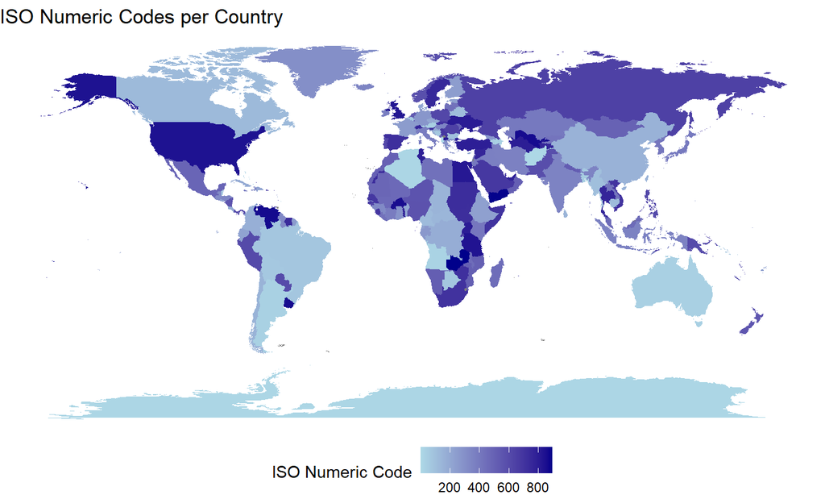

```r
plot
```

## What I Learned

- How to make my RMarkdown into a slide show: [isoslides](https://bookdown.org/yihui/rmarkdown/ioslides-presentation.html#custom-templates-2), and how to make it [scroll](https://stackoverflow.com/questions/53064555/how-to-make-scrollable-slides-in-an-ioslides-presentation-with-rmarkdown).
- How to join two data sets without the column names matching. During my data wrangling, I used the code - left_join(iso_data, by= c(“region” = “name”)) . “region” is from the world_map dataframe and “name” is from the iso_data dataframe.
- How to search for mismatched words between two drataframes.

## What I Practiced

- I realized I have not practiced making a map outside of the one we did in lecture. I figured this dataset is a perfect opportunity to practice this skill!
- Renaming a million words to match across two dataframes :)